# Tidy Text Example

Alfredo

4/7/2021

### Arthur Connan Doyle

Let’s import and visualize three books by the author of Sherlock Holmes from the [Gutenberg Project](https://www.gutenberg.org/). We will use the following packages:

- `library(tidytext)`
- `library(ggwordcloud)`
- `library(gutenbergr)`

```r
#Step 1: Get Unprocessed Text
raw_doyle <- gutenberg_download(c(108, 1661, 139))

raw_doyle <- raw_doyle %>%
  mutate(book=case_when(
    gutenberg_id==108~"The Return of Sherlock Holmes",
    gutenberg_id==1661~"The Adventures of Sherlock Holmes",
    gutenberg_id==139~"The Lost World",
  ))
head(raw_doyle)
```

```
## # A tibble: 6 x 3
##   gutenberg_id text                            book
##          <int> <chr>                           <chr>
## 1          108 "cover"                         The Return of Sherlock Holmes
## 2          108 ""                              The Return of Sherlock Holmes
## 3          108 ""                              The Return of Sherlock Holmes
## 4          108 ""                              The Return of Sherlock Holmes
## 5          108 "The Return of Sherlock Holmes" The Return of Sherlock Holmes
## 6          108 ""                              The Return of Sherlock Holmes
```

### Cleaning our text with `stringR`

We have a total of 3 books. Now let’s clean the text by removing capital letters, punctuation and digits.[^1]

```r
#Step 2: Clean Text
clean_doyle <- raw_doyle %>%
  mutate(
    text=tolower(text),
    text=str_remove_all(text,"[:punct:]"),
    text=str_remove_all(text,"[:digit:]")
         )
head(clean_doyle)
```

```
## # A tibble: 6 x 3
##   gutenberg_id text                            book
##          <int> <chr>                           <chr>
## 1          108 "cover"                         The Return of Sherlock Holmes
## 2          108 ""                              The Return of Sherlock Holmes
## 3          108 ""                              The Return of Sherlock Holmes
## 4          108 ""                              The Return of Sherlock Holmes
## 5          108 "the return of sherlock holmes" The Return of Sherlock Holmes
## 6          108 ""                              The Return of Sherlock Holmes
```

Now that our text is clean, we can move to the tokenization process. Before we do this however, let’s define a very useful function:

```r
`%notin%` <- Negate(`%in%`)
```

### Tokenization with `tidytext`

With this, we can move on to tokenize our words, remove stopwords, and remove some custom words that do not give us much information!

```r
tidy_doyle <- clean_doyle %>%
  #Tokenize by word
  unnest_tokens(word, text) %>%
  #Remove english stopwords
  anti_join(stop_words) %>%
  #Remove custom words
  filter(word %notin% c("holmes", "watson", "sherlock"))
head(tidy_doyle)
```

```
## # A tibble: 6 x 3
##   gutenberg_id book                          word
##          <int> <chr>                         <chr>
## 1          108 The Return of Sherlock Holmes cover
## 2          108 The Return of Sherlock Holmes return
## 3          108 The Return of Sherlock Holmes sir
## 4          108 The Return of Sherlock Holmes arthur
## 5          108 The Return of Sherlock Holmes conan
## 6          108 The Return of Sherlock Holmes doyle
```

The next step is creating some text summaries, for example, word counts:

```r
#Step 4: Summarize Tokens

tidy_doyle %>%
  group_by(book) %>%
  count(word, sort = T) %>%
  summarise(words=sum(n))
```

```
## # A tibble: 3 x 2
##   book                              words
##   <chr>                             <int>
## 1 The Adventures of Sherlock Holmes 31041
## 2 The Lost World                    25697
## 3 The Return of Sherlock Holmes     34128
```

```r
tidy_counts <- tidy_doyle %>%
  group_by(book) %>%
  count(word, sort = T)
```

### A `ggplot2` worldcloud

Finally, we are ready to make a visualization. Let’s make a wordcloud where each book has its own color!

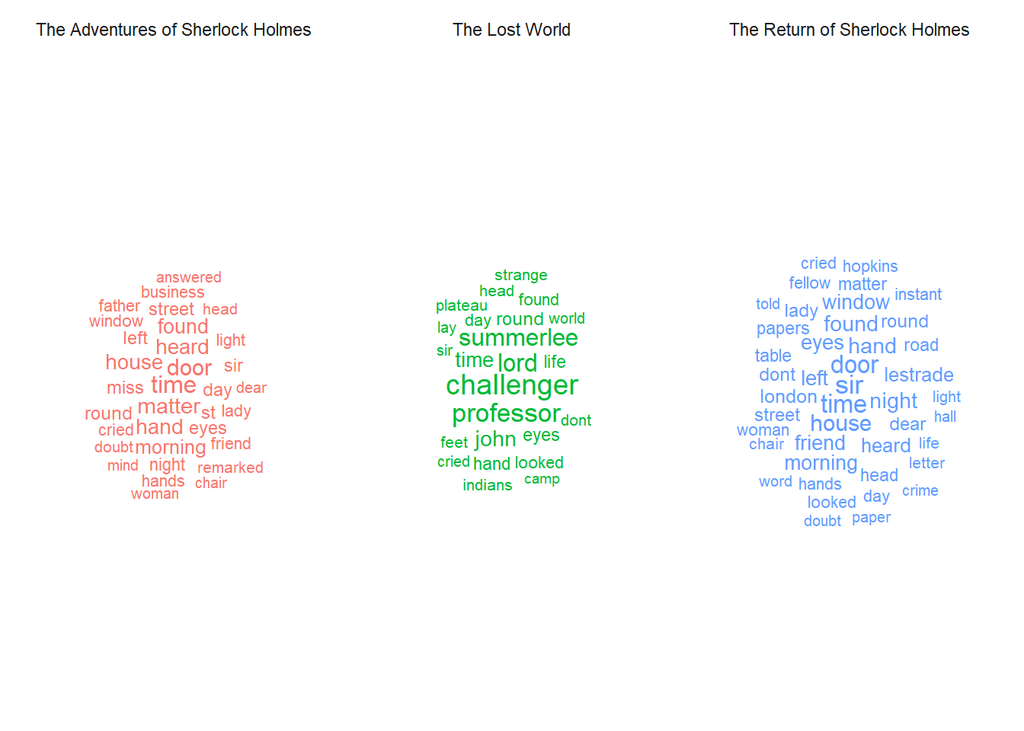

```r
tidy_counts %>%
  head(100) %>%
  ggplot(aes(label=word, size=n, color=book))+
  geom_text_wordcloud()+
  scale_size_area(max_size = 5) +
  facet_wrap(~book)+
  theme_minimal()
```

There are many things you can do with text data besides visualizations. If you want to learn more about *text analytics*, consider going over the book [Text Mining with R](https://www.tidytextmining.com/) by Julia Silge.

[^1]: There are many text cleaning methods, but I recommend using the `stringR` [package](https://stringr.tidyverse.org/).